# Curso de Inferência Causal

# Métodos de ajuste para confundimento

- Randomização - ideal
- Métodos generalizados:
  - Padronizacao - fórmula g paramétrica
  - Ponderação pelo inverso da probabilidade de seleção em modelos estruturais marginais
  - Estimação g de modelos estruturais aninhados
- Métodos baseados em estratificação:
  - Esratificação (não paramétrica) - regressão (paramétrica)
  - Restrição
  - Pareamento - escores de propensão

# Exemplo (Hernan & Robins, 2019)

| L | A | Y |
| --- | --- | --- |
| 0 | 0 | 0 |
| 0 | 0 | 1 |
| 0 | 0 | 0 |
| 0 | 0 | 0 |
| 0 | 1 | 0 |
| 0 | 1 | 0 |
| 0 | 1 | 0 |
| 0 | 1 | 0 |
| 1 | 0 | 1 |
| 1 | 0 | 1 |
| 1 | 0 | 0 |
| 1 | 1 | 1 |
| 1 | 1 | 1 |
| 1 | 1 | 1 |
| 1 | 1 | 1 |
| 1 | 1 | 1 |
| 1 | 1 | 1 |
| 1 | 1 | 0 |
| 1 | 1 | 0 |
| 1 | 1 | 0 |

A -> Tratamento (transplante=1, sem transplante=0)  
Y -> Desfecho (morreu=1; não morreu=0)  
L -> Gravidade (pct grave=1; pct não grave=0)

por permutabilidade:
$$Pr[Y=1|A=1] = Pr[Y^{a=1}=1]$$

por permutabilidade:
$$Pr[Y=1|A=0] = Pr[Y^{a=0}=1]$$

L=0 -> 1/4=0.25 -> 40% (8/20 - não graves)  
L=1 -> 2/3=0.66 -> 60% (12/20 - graves)  
`0.25*0.40 + 0.66*0.60 = 0.1+0.4=0.5`

Fórmula de ajuste:
$$\sum_{l} Pr[Y|L=l, A=a] * Prob[L=l]$$

Método não paramétrico, usado para poucos confundidores

# Ponderação pelo inverso da probabilidade de seleção

1. Calcular a probabilidade de seleção para cada indivíduo
2. Ponderar a estimativa pelo inverso desta probabilidade de seleção

Os indiv;iduos que tiverem **maior** probabilidade de serem selecionados para receber o tratamento terão um peso **menor**.  
Os indivíduos que tiverem **menor** probabilidade de serem selecionados para receber o tratamento terão um peso **maior**.

OBJETIVO -> balancear o estudo

Mesmo Exemplo (Hernan & Robins, 2019)

1. Calcular a probabilidade de seleção para cada indivíduo:  
   Probabilide de ser tratado não sendo grave -> 4/8 = 0.50  
   Probabilide de não ser tratado não sendo grave -> 4/8 = 0.50  
   Probabilide de ser tratado sendo grave -> 9/12 = 0.75  
   Probabilide de não ser tratado sendo grave -> 3/12 = 0.25
2. Ponderar a estimativa pelo inverso desta probabilidade de seleção:  
   não grave tratado -> 1/0.5=2  
   não grave não tratado -> 1/0.5=2  
   grave tratado -> 1/0.75=1.33  
   grave não tratado -> 1/0.25=4

# Modelo expplicativo estrutural marginal

- Estrutural: respostas contrafatuais
- Marginal (não condicional): não inclui nenhuma covariável (saturado)

Exemplo:  
Fumar durante a gravidez gera algum efeito no peso ao nascer?

Y (desfecho) -> peso ao nascer  
T (exposição) -> mãe fumante ou não fumente  
C (confundidor) -> Idade da mãe

# Escore de propensão

Probabilidade condicional de tratameto

$$Pr[T=1|C]$$

Qual a probabilidade da mãe fumar, em função da sua idade?

# Cálculo dos pesos para tratamento binário

- Para os expostos ou grupo de tratamento:

Fumantes

$$W^{T}=1/Pr[T=1|C]$$

- Para os não expostos ou grupo controle:

Não fumantes

$$W^{T}=1/(1-Pr[T=1|C])$$

# Modelo preditivo logístico

Modelo `idade[C] ~ fumar[T]`: qual a probabilidade de fumar em função da idade da mãe?

Predict_pf = predição da probabilidaed de fumar (OR)  
ipf = if_else(smoke == 1, 1/Predict_pf, 1/(1-Predict_pf))

Inverso da probabilidade de fumar adicionado como peso no modelo `peso[Y] ~ fumar[T], weight=ipf`

# Verificar balanço - permutabilidade

pacote `ipw::tableOne`

Diferenças nas médias padronizadas devem ser próximas de zero e a razão de variância deve ser próxima de 1

Avaliar com `density_plot`

# Cálculo dos pesos para o inverso da probabilidade de seleção

- **Confundimento:** probabilidade de tratamento em função das variáveis preditoras do tratamento

$$W^{T}=\frac{1}{f(T|C)}$$

- **Viés de seleção:** probabilidade de participação no estudo em função das variáveis (tratamento e confundidoras)

$$W^{Part}=\frac{1}{Pr[Part=1|T,Preditores]}$$

- **Peso Final** $=W^{T}*W^{Part}$

# Passos na análise com escore de propensão

1. Análise ajustada em modelos de regresão convencionais
2. Verificação do balanceamento antes da implementação do escore de propensão
3. Estimação do escorte de propensão
4. Ponderação ou pareamento com escore de propensão
5. Verificação do balanceamento depois da implementação do escore de propensão
6. Cálculo do efeito causal em modelos ponderados ou com pareamento pelo escore de propensão

# Exemplo

# Verificar balanceamento entre tratados e não tratados

- Variáveis contínuas -> teste t de Student
- Valriáveis categóricas -> teste do chi-quadrado
- Problemas: dependente do tamanho da amostra
  - Amostras pequenas -> falso negativo
  - Amostras grandes -> significante, mas importante?

# Outros métodos

- Diferença absoluta nas médias padronizadas entre os grupos tratamento e controle

$$\frac{\bar{x}_ {t}-\bar{x}_{c}}{\sqrt{}(s^{2}_{t}+s^{2}_{c})/2}$$

Ideal < 0.10 desvio padrão  
Aceit;avel < 0.25 desvio padrão

- Teste de Kolmogorov-Smirnov -> compara toda a distribuição (p>=0.05)
- Quais variáveis incluir no ajuste?
  - Pela significância?
  - Pela teora?

# Seleção de covariáveis (Leite, 2017)

INCLUIR COM BASE NA TEORIA  
- Confundidores - causa do tratamento e do desfecho diminui viés e diminui variância  
- Preditores do desfecho dimunui variância, mas quebra cegamento  
- menor erro de mensuração

NÃO INCLUIR  
- Preditores do tratamento aumaenta a variância  
- Mediadores  
- Descendentes dos tratamento  
- Colisores

SELECIONAR COM APOIO DE DAG (Gráfico Acíclico Direcionado)  
- Criério da porta de trás

# Variável quantitativa - idade

```r
library(Matching)
data("lalonde")

t.test(age~treat, data=lalonde, var.equal=TRUE)
```

```
##
##  Two Sample t-test
##
## data:  age by treat
## t = -1.1166, df = 443, p-value = 0.2648
## alternative hypothesis: true difference in means between group 0 and group 1 is not equal to 0
## 95 percent confidence interval:
##  -2.1042036  0.5794635
## sample estimates:
## mean in group 0 mean in group 1
##        25.05385        25.81622
```

# Variável qualitativa - Casados

```r
descr::crosstab(lalonde$treat, lalonde$married, prop.r = TRUE, chisq = TRUE, plot = FALSE)
```

```
##    Conteúdo das células
## |-------------------------|
## |                Contagem |
## |    Percentual por linha |
## |-------------------------|
##
## ======================================
##                  lalonde$married
## lalonde$treat        0       1   Total
## --------------------------------------
## 0                 220      40     260
##                  84.6%   15.4%   58.4%
## --------------------------------------
## 1                 150      35     185
##                  81.1%   18.9%   41.6%
## --------------------------------------
## Total             370      75     445
## ======================================
##
## Estatísticas para todos os fatores da tabela
##
## Pearson's Chi-squared test
## ------------------------------------------------------------
## Qui² = 0.9634957      g.l. = 1      p = 0.326
##
## Pearson's Chi-squared test with Yates' continuity correction
## ------------------------------------------------------------
## Qui² = 0.7277914      g.l. = 1      p = 0.394
##         Frequência esperada mínima: 31.17978
```

# Diferença entre tratados e controles

```r
library(tidyverse)

xvars <- c("age", "re74", "re75", "educ", "nodegr", "married", "black", "hisp")

table1 <- tableone::CreateTableOne(vars = xvars,
                                   strata = "treat",
                                   data = lalonde %>% mutate(nodegr = factor(nodegr),
                                                             married = factor(married),
                                                             black = factor(black),
                                                             hisp = factor(hisp)),
                                   test = TRUE)

print(table1, smd = TRUE)
```

```
##                   Stratified by treat
##                    0                 1                 p      test SMD
##   n                    260               185
##   age (mean (SD))    25.05 (7.06)      25.82 (7.16)     0.265       0.107
##   re74 (mean (SD)) 2107.03 (5687.91) 2095.57 (4886.62)  0.982       0.002
##   re75 (mean (SD)) 1266.91 (3102.98) 1532.06 (3219.25)  0.382       0.084
##   educ (mean (SD))   10.09 (1.61)      10.35 (2.01)     0.135       0.141
##   nodegr = 1 (%)       217 (83.5)        131 (70.8)     0.002       0.305
##   married = 1 (%)       40 (15.4)         35 (18.9)     0.394       0.094
##   black = 1 (%)        215 (82.7)        156 (84.3)     0.744       0.044
##   hisp = 1 (%)          28 (10.8)         11 ( 5.9)     0.109       0.175
```

# Prática usual

Estimar efeito do tratamento em um modelo de regressão com ajuste para fatores de confusão

```r
reg <- lm(re78 ~ treat + age + educ + black + hisp + nodegr + married + re74 + re75, data = lalonde)

reg %>% summary
```

```
##
## Call:
## lm(formula = re78 ~ treat + age + educ + black + hisp + nodegr +
##     married + re74 + re75, data = lalonde)
##
## Residuals:
##    Min     1Q Median     3Q    Max
##  -9776  -4425  -1645   2942  54107
##
## Coefficients:
##               Estimate Std. Error t value Pr(>|t|)
## (Intercept)  7.851e+02  3.375e+03   0.233  0.81617
## treat        1.676e+03  6.387e+02   2.625  0.00898 **
## age          5.532e+01  4.528e+01   1.222  0.22254
## educ         3.957e+02  2.274e+02   1.740  0.08254 .
## black       -2.160e+03  1.169e+03  -1.847  0.06539 .
## hisp         1.640e+02  1.549e+03   0.106  0.91574
## nodegr      -7.068e+01  1.004e+03  -0.070  0.94393
## married     -1.387e+02  8.797e+02  -0.158  0.87477
## re74         8.214e-02  7.742e-02   1.061  0.28930
## re75         5.276e-02  1.355e-01   0.389  0.69712
## ---
## Signif. codes:  0 '***' 0.001 '**' 0.01 '*' 0.05 '.' 0.1 ' ' 1
##
## Residual standard error: 6513 on 435 degrees of freedom
## Multiple R-squared:  0.05483,    Adjusted R-squared:  0.03527
## F-statistic: 2.804 on 9 and 435 DF,  p-value: 0.00329
```

# Problemas (da modelagem convencional)

- Forma funcional da relação entre os preditores e o desfecho é linear?
- Ausência de interações?
- Não é possível saber se as variáveis ficaram balanceadas após o ajuste - permutabilidade?

Solução: modelagem em duas etapas

# Escore de propensão

- Potencial para balancear variáveis observadas
- Probabilidade condicional de receber o tratamento em função das variáveis preditoras obseradas

$$E[p] = Pr(t=1|p)$$

# Estimador em dois passos

- **MODELO PREDITIVO** - Estimar a probabilidade de ser treinado em função das variáveis preditoras do treinamento (modelo logístico)
- **MODELO EXPLICATIVO** - Estimar a diferença entre as médias de renda em 1978 entre os grupos que receberam treinamento ou não, pondernado pelo inverso da probabilidade de ter sido treinado (modelo de regressão linear)

# Escore de propensão

Probabilidade condicional de tratamento em função de variáveis preditoras do tratamento (características pré-tratamento)

$$E[p]=Pr(t=1|p)$$

*Qual a probabilidade do indivíduo ter sido treinado, em função das variáveis preditoras (raça, ser casado, renda em 1974, idade, educação)?*

# Métodos para estimativa do escore de propensão

- Regressão logística
  1. Má especificação - não inclusão de termos polinomiais e interações - provoca não balanceamento
  2. Verificar linearidade do logito para variáveis contínuas - sensível à forma funcional
- Modelagem Ampliada Generalizada (*Generalized Boosted Model* - GBM) - Apredizagem de máquinas baseada em árvores de decisão e algorítmos iterativos - seleciona automaticamente covariáveis, termos polinomiais e interações para incluir no balanceamento

# Tipos de efeito causal

*Average Treatment Effect* - ATE  
- $ATE=E[D^{1}-D^{0}]$  
- Qual a eficácial relativa do tratamento em média na população?

*Average Treatment Effect Among the Treatment* - ATT  
- $ATT=E[D^{1}-D^{0}|T=1]$  
- Que resultado teriam os indivíduos do grupo controle se eles tivessem recebido o tratamento?

*Average Treatment Effect Among the Control* - ATC  
- $ATT=E[D^{1}-D^{0}|T=0]$

**Obs:** Em estudos controlados e aleatorizados $ATE = ATT$

# Verificar área de suporte comum

Qual estmativa de efeito causal será usada?

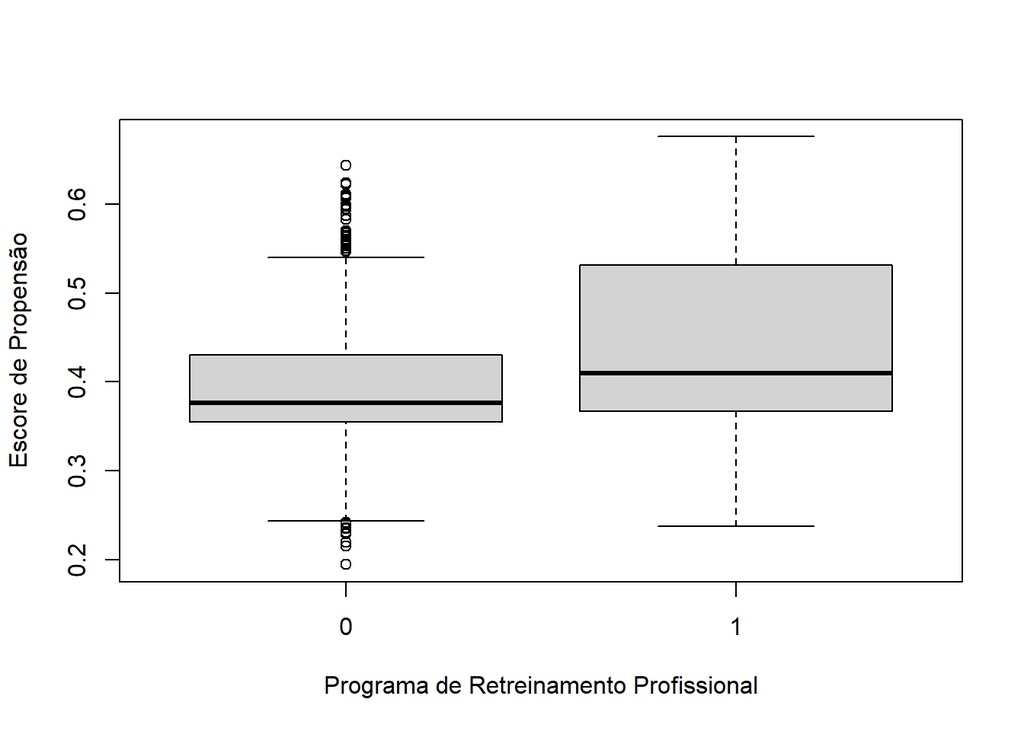

```r
red_prop <- glm(treat ~ age + re74 + re75 + educ + nodegr + married + black + hisp,
                data = lalonde, family = binomial(link = "logit"))

pscore <- red_prop$fitted.values

lalonde %>%
  cbind(pscore) %>%
  boxplot(pscore~treat, data=.,
          xlab = "Programa de Retreinamento Profissional",
          ylab = "Escore de Propensão")
```

# Cácilo dos pesos para tratamento binário - ATE

- Para os expostos ou grupo de tratamento:
  Treinados
  $$Peso^{T}=\frac{1}{Pr[T=1|P]}$$
- Para os não expostos ou grupo controle:
  Não Treinados
  $$Peso^{T}=\frac{1}{(1-Pr[T=1|P])}$$

# Cácilo dos pesos para tratamento binário - ATT

- Para os expostos ou grupo de tratamento:
  Treinados
  $$Peso^{T}=1$$
- Para os não expostos ou grupo controle:
  Não Treinados
  $$Peso^{T}=\frac{Pr[T=1|P]}{(1-Pr[T=1|P])}$$

# Estimativa do escore de propensão por regressão logística

```r
lalonde$peso.ATE <- if_else(lalonde$treat == 1, 1/pscore, 1/(1-pscore))
lalonde$pslog <- pscore

lalonde %>%
  select(treat, age, educ, black, hisp, married, nodegr, re74, re75, pslog, peso.ATE) %>%
  head(10) %>% kableExtra::kable() %>% kableExtra::kable_styling()
```

| treat | age | educ | black | hisp | married | nodegr | re74 | re75 | pslog | peso.ATE |
| --- | --- | --- | --- | --- | --- | --- | --- | --- | --- | --- |
| 1 | 37 | 11 | 1 | 0 | 1 | 1 | 0 | 0 | 0.4021026 | 2.486927 |
| 1 | 22 | 9 | 0 | 1 | 0 | 1 | 0 | 0 | 0.2466787 | 4.053856 |
| 1 | 30 | 12 | 1 | 0 | 0 | 0 | 0 | 0 | 0.5594794 | 1.787376 |
| 1 | 27 | 11 | 1 | 0 | 0 | 1 | 0 | 0 | 0.3526728 | 2.835489 |
| 1 | 33 | 8 | 1 | 0 | 0 | 1 | 0 | 0 | 0.4096518 | 2.441098 |
| 1 | 22 | 9 | 1 | 0 | 0 | 1 | 0 | 0 | 0.3802885 | 2.629582 |
| 1 | 23 | 12 | 1 | 0 | 0 | 0 | 0 | 0 | 0.5513589 | 1.813701 |
| 1 | 32 | 11 | 1 | 0 | 0 | 1 | 0 | 0 | 0.3580540 | 2.792875 |
| 1 | 22 | 16 | 1 | 0 | 0 | 0 | 0 | 0 | 0.4791392 | 2.087076 |
| 1 | 33 | 12 | 0 | 0 | 1 | 0 | 0 | 0 | 0.6550839 | 1.526522 |

```r
lalonde %>%
  select(treat, age, educ, black, hisp, married, nodegr, re74, re75, pslog, peso.ATE) %>%
  tail(10) %>% kableExtra::kable() %>% kableExtra::kable_styling()
```

|  | treat | age | educ | black | hisp | married | nodegr | re74 | re75 | pslog | peso.ATE |
| --- | --- | --- | --- | --- | --- | --- | --- | --- | --- | --- | --- |
| 436 | 0 | 30 | 11 | 1 | 0 | 1 | 1 | 0.000 | 9311.94 | 0.5359700 | 2.155033 |
| 437 | 0 | 25 | 10 | 1 | 0 | 1 | 1 | 13520.000 | 9319.44 | 0.4415136 | 1.790554 |
| 438 | 0 | 28 | 11 | 1 | 0 | 1 | 1 | 824.389 | 10033.90 | 0.5382142 | 2.165506 |
| 439 | 0 | 22 | 10 | 0 | 0 | 0 | 1 | 27864.400 | 10598.70 | 0.3629381 | 1.569706 |
| 440 | 0 | 44 | 9 | 1 | 0 | 1 | 1 | 12260.800 | 10857.20 | 0.5150030 | 2.061868 |
| 441 | 0 | 21 | 9 | 1 | 0 | 0 | 1 | 31886.400 | 12357.20 | 0.3230954 | 1.477313 |
| 442 | 0 | 28 | 11 | 1 | 0 | 0 | 1 | 17491.500 | 13371.30 | 0.4178326 | 1.717719 |
| 443 | 0 | 29 | 9 | 0 | 1 | 0 | 1 | 9594.310 | 16341.20 | 0.4061330 | 1.683879 |
| 444 | 0 | 25 | 9 | 1 | 0 | 1 | 1 | 24731.600 | 16946.60 | 0.4879397 | 1.952895 |
| 445 | 0 | 22 | 10 | 0 | 0 | 1 | 1 | 25720.900 | 23032.00 | 0.6070143 | 2.544622 |

# Modelo explicativo

Ponderado pelo inverso da probabilidade de seleção (tratamento)

```r
design_pslog <- survey::svydesign(ids = ~1, weights = ~peso.ATE, data = lalonde)

glm <- survey::svyglm(re78 ~ treat, design = design_pslog)

glm %>% summary
```

```
##
## Call:
## svyglm(formula = re78 ~ treat, design = design_pslog)
##
## Survey design:
## survey::svydesign(ids = ~1, weights = ~peso.ATE, data = lalonde)
##
## Coefficients:
##             Estimate Std. Error t value Pr(>|t|)
## (Intercept)   4549.8      343.2  13.257   <2e-16 ***
## treat         1641.3      686.3   2.392   0.0172 *
## ---
## Signif. codes:  0 '***' 0.001 '**' 0.01 '*' 0.05 '.' 0.1 ' ' 1
##
## (Dispersion parameter for gaussian family taken to be 45934134)
##
## Number of Fisher Scoring iterations: 2
```

# Escore de popensão

- Estimar efeito causal na ausência de randomização
- Não há permutabilidade
- Os fatores determinantes do tratamento são conhecidos
- Recuperar a permutabilidade entre os grupos de tratamento e controle - controlar viés de seleção

# Exemplo (McKee, 2015)

cmi -> Ceficiente de Mortalidade Infantil (desfecho)

```r
mckee <- tibble(obs = c(1, 2, 3, 4, 5, 6, 7, 8, 9),
       treat = c(1, 1, 1, 1, 0, 0, 0, 0, 0),
       cmi = c(10, 15, 22, 19, 25, 19, 4, 8, 6),
       pobreza = c(.5, .8, .7, .6, .6, .5, .1, .3, .2),
       medico = c(.01, .02, .01, .02, .01, .02, 0.4, .05, .04))

mckee %>% kableExtra::kable() %>% kableExtra::kable_styling()
```

| obs | treat | cmi | pobreza | medico |
| --- | --- | --- | --- | --- |
| 1 | 1 | 10 | 0.5 | 0.01 |
| 2 | 1 | 15 | 0.8 | 0.02 |
| 3 | 1 | 22 | 0.7 | 0.01 |
| 4 | 1 | 19 | 0.6 | 0.02 |
| 5 | 0 | 25 | 0.6 | 0.01 |
| 6 | 0 | 19 | 0.5 | 0.02 |
| 7 | 0 | 4 | 0.1 | 0.40 |
| 8 | 0 | 8 | 0.3 | 0.05 |
| 9 | 0 | 6 | 0.2 | 0.04 |

# Estimador em três passos

1. **MODELO PREDITIVO** - Estimar a probabilidade de cada vila participar do programa em função das variáveis preditoras da participação (modelo logístico)
2. **PAREAMENTO COM BASE NO ESCORE DE PROPENSÃO** - ex: Vizinhos mais próximos
3. **MODELO EXPLICATIVO PÓS-PAREAMENTO** - Estimar a diferença na mortalidade infantil entre as vilas que receberam o programa ou não (modelo de regressão linear) no arquivo pareado

# Comparação Naive

Compara média entre grupos tratamento e controle

```r
mckee %>% t.test(cmi~treat, data=.) %>% parameters::model_parameters()
```

```
## Welch Two Sample t-test
##
## Parameter | Group | treat = 0 | treat = 1 | Difference |         95% CI | t(6.48) |     p
## -----------------------------------------------------------------------------------------
## cmi       | treat |     12.40 |     16.50 |      -4.10 | [-15.73, 7.53] |   -0.85 | 0.427
##
## Alternative hypothesis: true difference in means between group 0 and group 1 is not equal to 0
```

# Grupo intervenção

- Maior mortalidade infantil
- Maior taxa de pobreza
- Menos taxa de médicos per capita

Possível viés de seleção: selecionaram para o tratamento as vilas que nessessitavam maior apoio

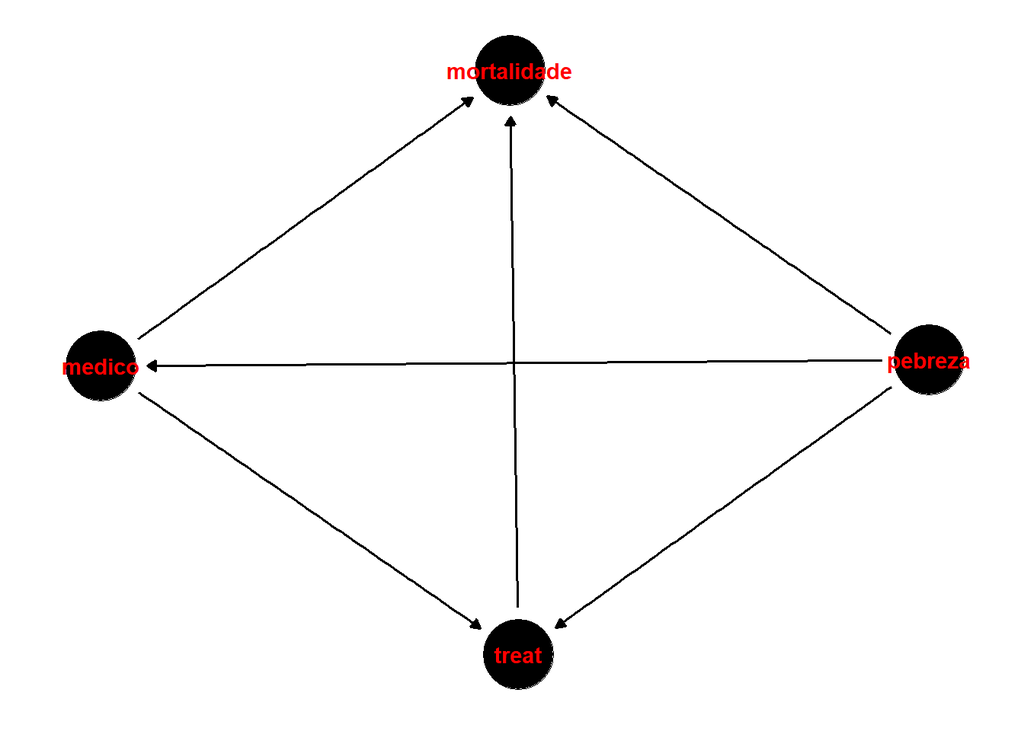

```r
library(ggdag)
library(ggplot2)

dagified <- ggdag::dagify(treat ~ pebreza,
                   treat ~ medico,
                   medico ~ pebreza,
                   mortalidade ~ pebreza,
                   mortalidade ~ medico,
                   mortalidade ~ treat,
                   labels = c("treat" = "Tratamento",
                              "medico" = "Medico percapita",
                              "pebreza" = "Nivel de pobreza",
                              "mortalidade" = "Mortalidade infantil"),
                   exposure = "treat",
                   outcome = "mortalidade", latent = c("medico", "pebreza")
                  )

ggdag::ggdag(dagified, text_col = "red"
             # text = FALSE, use_labels = "label"
             ) + theme_dag()
```

# Solução usual

Modelo de regressão ajustado para confundidores

```r
glm(cmi ~ treat + medico + pobreza , data = mckee) %>% summary
```

```
##
## Call:
## glm(formula = cmi ~ treat + medico + pobreza, data = mckee)
##
## Deviance Residuals:
##       1        2        3        4        5        6        7        8
## -0.8168  -7.1832   3.6114   4.3886   2.8389   0.6161   0.4273  -2.8384
##       9
## -1.0438
##
## Coefficients:
##             Estimate Std. Error t value Pr(>|t|)
## (Intercept)  -0.5629     5.8127  -0.097   0.9266
## treat        -7.5584     4.3252  -1.748   0.1410
## medico        0.8744    17.2967   0.051   0.9616
## pobreza      37.8588    12.2096   3.101   0.0268 *
## ---
## Signif. codes:  0 '***' 0.001 '**' 0.01 '*' 0.05 '.' 0.1 ' ' 1
##
## (Dispersion parameter for gaussian family taken to be 20.46702)
##
##     Null deviance: 451.56  on 8  degrees of freedom
## Residual deviance: 102.34  on 5  degrees of freedom
## AIC: 57.42
##
## Number of Fisher Scoring iterations: 2
```

Problema: não leva em conta relações não lineares e interações entre as variáveis

# Solução

- Criar novo grupo controle - pareamento
- Para cada vila do grupo de tratamento - selecionar uma vila do grupo controle que seja a mais parecida com ela em termos de características prévias
- Que seja semelhante em relação às variáveis preditoras do pareamento

# Opção de pareamento manual

- Com reposição
  - 1 com 6
  - 2 com 5
  - 3 com 5
  - 4 com 5
- 7, 9, 0 descartadas

# Estimar escore de propensão

- Problema: como identificar a melhor observação controle quando são muitas as variáveis determinantes do tratamento
- Solução: calcular a probabilidade de receber a intervenção em função das variáveis preditoras:
  - $Prob[treat=1|X1, X2]$

# Escore de propensão

- É a probabilidade condicional (predita) de tratamento em função das características pré-tratamento (determeinates do tratamento)
- Abordagem contrafatual - comparar o desfecho nos tratados com os controles (representam os tratados se estes não tivessem sido tratados) - permutabilidade
- Estimativa marginal do efeito causal

# Modelo logístico

```r
modelo <- glm(treat ~ pobreza + medico, data = mckee, family = binomial(link = "logit"))
modelo %>% summary
```

```
##
## Call:
## glm(formula = treat ~ pobreza + medico, family = binomial(link = "logit"),
##     data = mckee)
##
## Deviance Residuals:
##      Min        1Q    Median        3Q       Max
## -1.60174  -0.15989  -0.00006   0.45306   1.31101
##
## Coefficients:
##             Estimate Std. Error z value Pr(>|z|)
## (Intercept)   -6.265      7.700  -0.814    0.416
## pobreza       12.668     11.686   1.084    0.278
## medico       -37.776    156.621  -0.241    0.809
##
## (Dispersion parameter for binomial family taken to be 1)
##
##     Null deviance: 12.365  on 8  degrees of freedom
## Residual deviance:  6.317  on 6  degrees of freedom
## AIC: 12.317
##
## Number of Fisher Scoring iterations: 9
```

```r
mckee$ps <- modelo$fitted.values

mckee %>% kableExtra::kable() %>% kableExtra::kable_styling()
```

| obs | treat | cmi | pobreza | medico | ps |
| --- | --- | --- | --- | --- | --- |
| 1 | 1 | 10 | 0.5 | 0.01 | 0.4234265 |
| 2 | 1 | 15 | 0.8 | 0.02 | 0.9574623 |
| 3 | 1 | 22 | 0.7 | 0.01 | 0.9024599 |
| 4 | 1 | 19 | 0.6 | 0.02 | 0.6411392 |
| 5 | 0 | 25 | 0.6 | 0.01 | 0.7227350 |
| 6 | 0 | 19 | 0.5 | 0.02 | 0.3348167 |
| 7 | 0 | 4 | 0.1 | 0.40 | 0.0000000 |
| 8 | 0 | 8 | 0.3 | 0.05 | 0.0127005 |
| 9 | 0 | 6 | 0.2 | 0.04 | 0.0052599 |

- **ATT** - Efeito médio do tratamento para os tratados
- Foram selecionadas para controle somente as vilas que se parecem com as vilas do grupo de tratamento e não com a população geral
- Diminui a área de suporte comum

# Verificar área de suporte comum

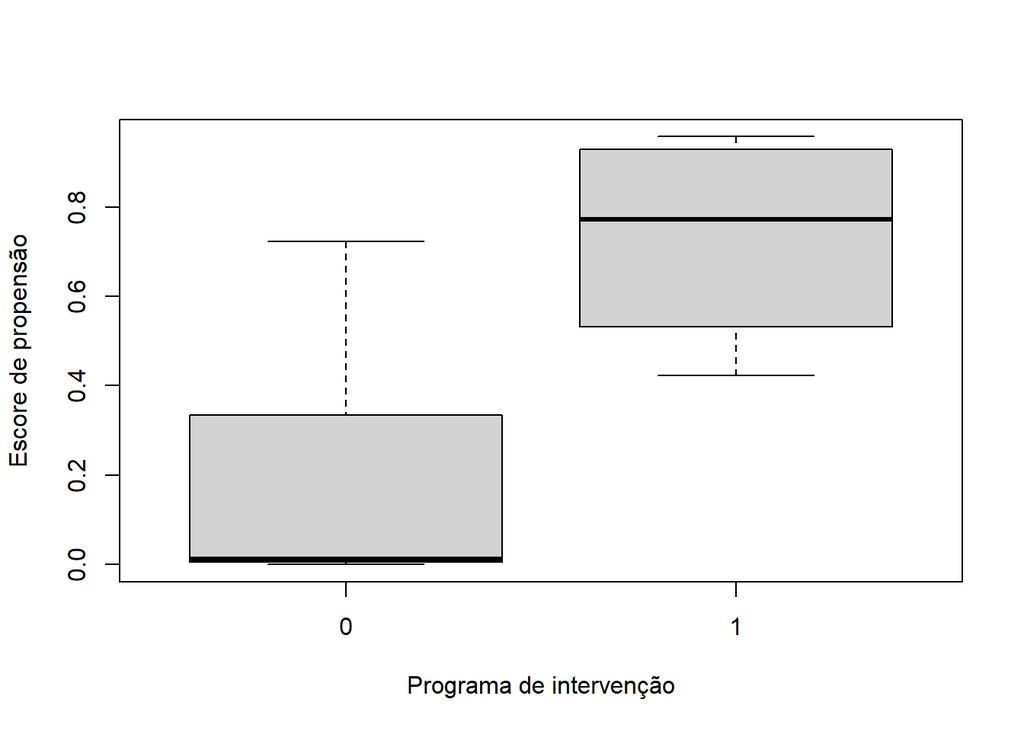

```r
mckee %>%
  boxplot(ps ~ treat, data = .,
          xlab = "Programa de intervenção",
          ylab = "Escore de propensão")
```

- Para pareamento:
  - ATT - todos os casos teriam controles?
  - ATE - todos os casos terima controles e todos os controles teriam casos?

```r
mckee %>% kableExtra::kable() %>% kableExtra::kable_styling()
```

| obs | treat | cmi | pobreza | medico | ps |
| --- | --- | --- | --- | --- | --- |
| 1 | 1 | 10 | 0.5 | 0.01 | 0.4234265 |
| 2 | 1 | 15 | 0.8 | 0.02 | 0.9574623 |
| 3 | 1 | 22 | 0.7 | 0.01 | 0.9024599 |
| 4 | 1 | 19 | 0.6 | 0.02 | 0.6411392 |
| 5 | 0 | 25 | 0.6 | 0.01 | 0.7227350 |
| 6 | 0 | 19 | 0.5 | 0.02 | 0.3348167 |
| 7 | 0 | 4 | 0.1 | 0.40 | 0.0000000 |
| 8 | 0 | 8 | 0.3 | 0.05 | 0.0127005 |
| 9 | 0 | 6 | 0.2 | 0.04 | 0.0052599 |

```r
(10+15+22+19)/4 - (19+25+25+25)/4
```

```
## [1] -7
```

# Passos

- Escolher variáveis que influenciam o tratamento
- Calcular o escore de propensão
- Parear pelo escore de propensão
- Checar se balanço foi atingido
- Calcula efeito causal

# Escore de propensão

- Logito do escore de propensão - resolve o problema quando os escores ficam muito proximos de zero ou de um
- Escores das vilas 7, 8 e 9 muito proximos de zero

$$log(e_{i}(p)) = log\left(\frac{e_{i}(p)}{1-e_{i}(p)}\right)$$

# Modelo logístico

Calcular e converter escore de propensão para logito

```r
mckee$pslogit <- log(mckee$ps/(1-mckee$ps))

mckee %>% kableExtra::kable() %>% kableExtra::kable_styling()
```

| obs | treat | cmi | pobreza | medico | ps | pslogit |
| --- | --- | --- | --- | --- | --- | --- |
| 1 | 1 | 10 | 0.5 | 0.01 | 0.4234265 | -0.3087227 |
| 2 | 1 | 15 | 0.8 | 0.02 | 0.9574623 | 3.1138950 |
| 3 | 1 | 22 | 0.7 | 0.01 | 0.9024599 | 2.2248602 |
| 4 | 1 | 19 | 0.6 | 0.02 | 0.6411392 | 0.5803121 |
| 5 | 0 | 25 | 0.6 | 0.01 | 0.7227350 | 0.9580688 |
| 6 | 0 | 19 | 0.5 | 0.02 | 0.3348167 | -0.6864794 |
| 7 | 0 | 4 | 0.1 | 0.40 | 0.0000000 | -20.1083993 |
| 8 | 0 | 8 | 0.3 | 0.05 | 0.0127005 | -4.3533323 |
| 9 | 0 | 6 | 0.2 | 0.04 | 0.0052599 | -5.2423671 |

# Checar balanço

- Balanço - determinar se foi atingido equilibrio entre os grupos de tratamento e controle
- Comparar grupo tratado com o novo grupo controle
1. Distribuição das variáveis preditoras do tratamento
2. Distribiução do escore de propensão

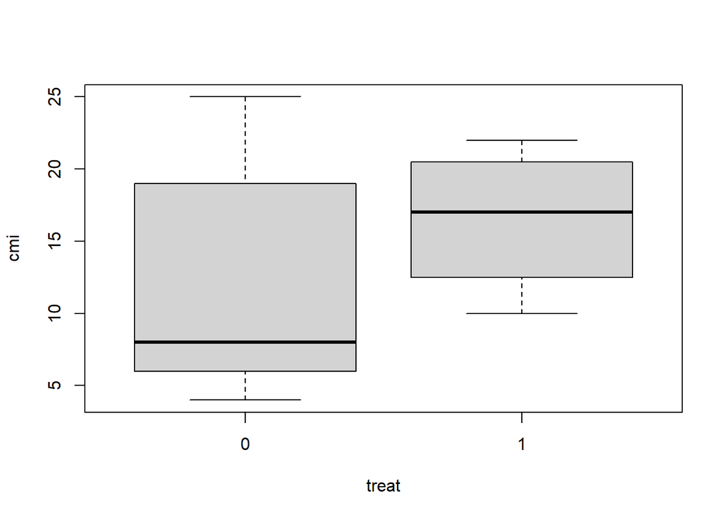

```r
mckee %>%
  boxplot(cmi ~ treat, data=.)
```

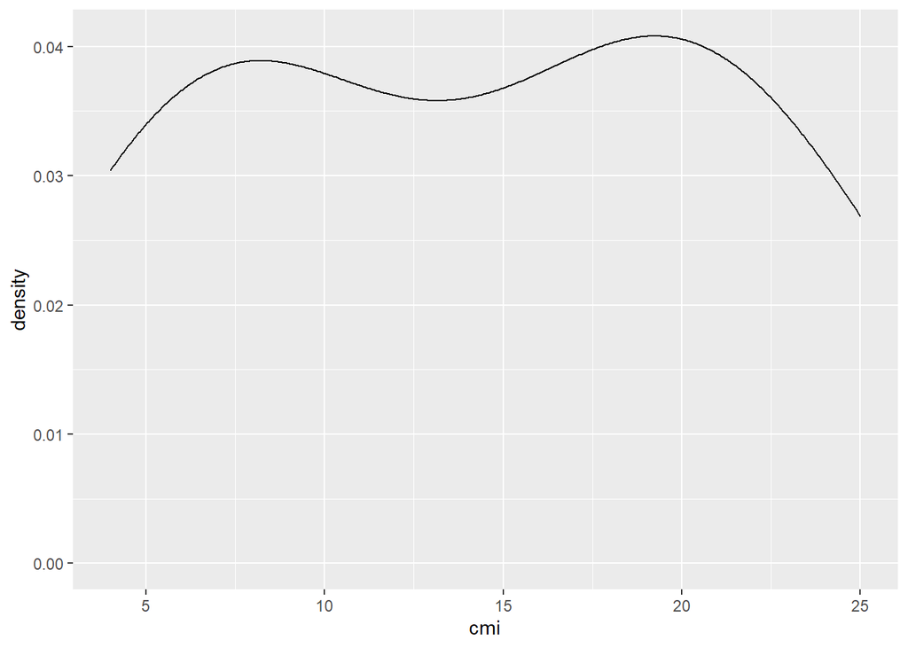

```r
mckee %>%
  ggplot(aes(x = cmi, color = treat)) +
  geom_density()
```

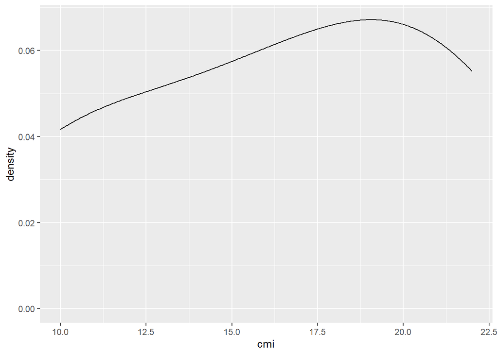

```r
mckee %>%
  filter(treat == 1) %>%
  ggplot(aes(x = cmi)) +
  geom_density()
```

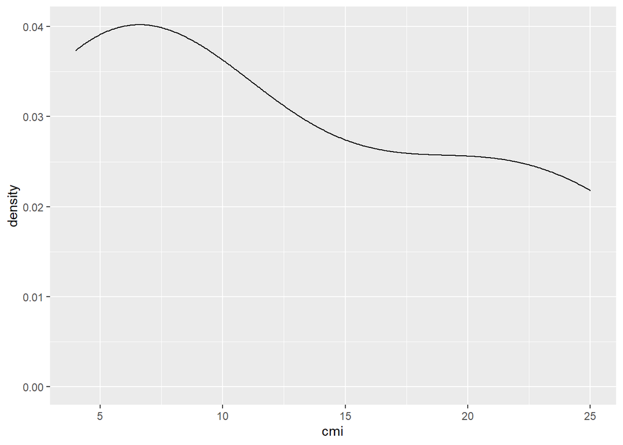

```r
mckee %>%
  filter(treat == 0) %>%
  ggplot(aes(x = cmi)) +
  geom_density()
```

# Pareamento - vizinho mais próximo - pacote Matchit

```r
nnmatch <- MatchIt::matchit(treat ~ pobreza + medico, data = mckee,
                            distance = "linear.logit", method = "nearest", ratio = 1)

summary(nnmatch, standardize = TRUE)
```

```
##
## Call:
## MatchIt::matchit(formula = treat ~ pobreza + medico, data = mckee,
##     method = "nearest", distance = "linear.logit", ratio = 1)
##
## Summary of Balance for All Data:
##          Means Treated Means Control Std. Mean Diff. Var. Ratio eCDF Mean
## distance        1.4026       -5.8865          4.7020     0.0345    0.4000
## pobreza         0.6500        0.3400          2.4012     0.3876    0.3571
## medico          0.0150        0.1040        -15.4153     0.0012    0.3000
##          eCDF Max
## distance      0.8
## pobreza       0.6
## medico        0.6
##
##
## Summary of Balance for Matched Data:
##          Means Treated Means Control Std. Mean Diff. Var. Ratio eCDF Mean
## distance        1.4026        -2.331          2.4085     0.2763    0.3333
## pobreza         0.6500         0.400          1.9365     0.5000    0.2857
## medico          0.0150         0.030         -2.5981     0.1000    0.2000
##          eCDF Max Std. Pair Dist.
## distance     0.75          2.4085
## pobreza      0.50          1.9365
## medico       0.50          3.4641
##
## Percent Balance Improvement:
##          Std. Mean Diff. Var. Ratio eCDF Mean eCDF Max
## distance            48.8       61.8      16.7      6.3
## pobreza             19.4       26.9      20.0     16.7
## medico              83.1       65.7      33.3     16.7
##
## Sample Sizes:
##           Control Treated
## All             5       4
## Matched         4       4
## Unmatched       1       0
## Discarded       0       0
```

Outro pacote

```r
matchps <- Matching::Match(Y = mckee$cmi, Tr = mckee$treat, X = mckee$ps, estimand = "ATT")
summary(matchps)
```

```
##
## Estimate...  -7
## AI SE......  1.8114
## T-stat.....  -3.8644
## p.val......  0.00011138
##
## Original number of observations..............  9
## Original number of treated obs...............  4
## Matched number of observations...............  4
## Matched number of observations  (unweighted).  4
```

```r
balance <- Matching::MatchBalance(treat ~ pobreza + medico,
                                  data = mckee,
                                  match.out = matchps)
```

```
##
## ***** (V1) pobreza *****
##                        Before Matching        After Matching
## mean treatment........       0.65               0.65
## mean control..........       0.34              0.575
## std mean diff.........     240.12             58.095
##
## mean raw eQQ diff.....       0.35              0.075
## med  raw eQQ diff.....        0.4               0.05
## max  raw eQQ diff.....        0.4                0.2
##
## mean eCDF diff........    0.35714             0.1875
## med  eCDF diff........        0.4              0.125
## max  eCDF diff........        0.6                0.5
##
## var ratio (Tr/Co).....     0.3876             6.6667
## T-test p-value........   0.029978            0.16815
## KS Bootstrap p-value..      0.148               0.43
## KS Naive p-value......    0.40047            0.69937
## KS Statistic..........        0.6                0.5
##
##
## ***** (V2) medico *****
##                        Before Matching        After Matching
## mean treatment........      0.015              0.015
## mean control..........      0.104             0.0125
## std mean diff.........    -1541.5             43.301
##
## mean raw eQQ diff.....     0.1025             0.0025
## med  raw eQQ diff.....      0.015                  0
## max  raw eQQ diff.....       0.38               0.01
##
## mean eCDF diff........        0.3              0.125
## med  eCDF diff........        0.3              0.125
## max  eCDF diff........        0.6               0.25
##
## var ratio (Tr/Co).....  0.0012064             1.3333
## T-test p-value........    0.29744            0.58903
## KS Bootstrap p-value..      0.128               0.72
## KS Naive p-value......    0.40047            0.99963
## KS Statistic..........        0.6               0.25
##
##
## Before Matching Minimum p.value: 0.029978
## Variable Name(s): pobreza  Number(s): 1
##
## After Matching Minimum p.value: 0.16815
## Variable Name(s): pobreza  Number(s): 1
```

# Problemas

- Amostra pequena - exemplo útil para desmonstrart como funciona o pareamento por escore de propensão
- O método não funciona bem quando quase todos aqueles com escores de propensão alto receberam o tratamento e quase todos com escore baixo não receberam - zona de suporte comum é pequena

# Vantagens do pareamento

1. Menos sensível à forma funcional da relação entre as varaáveis (interação e linearidade)
2. O balanço pode ser melhor verificado empiricamente

# Desvantagens do pareamento

- Perda de casos e controles - diminui área de suporte comum - diminui a generalização externa
- **Poderar com escore de propensão** - usa todos os sujeitos do estudo - aumenta o poder e a generalização externa

# Tipos de pareamento

- Com reposição - o mesmo controle pode ser pareado com vários casos - reduz viéz
- Sem reposição - o mesmo controle só é pareado uma vez com cada caso tratado - aumenta a probabilidade de pareamento ruim
- Razão entre casos e controles 1:1, n:1 (pareamento múltiplo - mais de um controle por caso)

# Tipos de pareamento

- **Vizinho mais próximo** - pareado com o controle que tiver o escore de propensão mais próximo, escolhendo-se o primeiro controle que atinge o critério
- **Vizinho mais próximo** fixando-se uma **distância máxima** (caliper) - geralmente 0.2 desvios padrão
- **Ótimo** - encontra os pares minimizando a distância absoluta média entre todos os pares - processo iterativo
- **Kernek** - cada tratado é pareado com vários controles com peso proporcional à distância entre o tratado em cada controle

# Modificar escore de propensão para melhorar a especificação do modelo

- Adicionar termos de interação
- Adicionar termos polinomiais - quadráticos, cúbicos

# Limitações

- Pareamento - perda de casos - dimimui a zona de suporte comum - diminui generalização externa
- Variáveis omitidas interferem na alocação do tratamento - quebra do pressuposto da ignorabilidade da alolcação do tratamento

$$(D^{1}, D^{0}) \perp\!\!\!\perp T|P$$

# Análise de sensibilidade

- Examinar qual magnitude um viés oculto por variáveis omitidas deve ter para modificar inferência
- Até que ponto os achados são sensíveis ao viés oculto?
- Rosenbaun (2002) - teste não paramétrico de Wilcoxon
- Cáculo do gamma - chance de viés oculto na alocação do tratamento
- Pacote `rbounds` R
- Quando os limites superior ou inferior do gamma mudarem de significante para não significante ou vice-versa -> indica o qunto a chance (gamma) precisa mudar para que a significância se modifique
- Resultado robusto -> mudança grande na chance necessária para provocar uma mudança na significância estatística

# Pareamento - vizinho mais próximo - pacote Matchit

```r
nnmatch <- MatchIt::matchit(treat ~ age + educ + black + hisp + nodegr + married + re74 + re75,
                            data = lalonde, distance = "linear.logit", method = "nearest", ratio = 1)

summary(nnmatch, standardize = TRUE)
```

```
##
## Call:
## MatchIt::matchit(formula = treat ~ age + educ + black + hisp +
##     nodegr + married + re74 + re75, data = lalonde, method = "nearest",
##     distance = "linear.logit", ratio = 1)
##
## Summary of Balance for All Data:
##          Means Treated Means Control Std. Mean Diff. Var. Ratio eCDF Mean
## distance       -0.2589       -0.4184          0.4006     1.0024    0.1117
## age            25.8162       25.0538          0.1066     1.0278    0.0254
## educ           10.3459       10.0885          0.1281     1.5513    0.0287
## black           0.8432        0.8269          0.0449          .    0.0163
## hisp            0.0595        0.1077         -0.2040          .    0.0482
## nodegr          0.7081        0.8346         -0.2783          .    0.1265
## married         0.1892        0.1538          0.0902          .    0.0353
## re74         2095.5740     2107.0268         -0.0023     0.7381    0.0192
## re75         1532.0556     1266.9092          0.0824     1.0763    0.0508
##          eCDF Max
## distance   0.2140
## age        0.0652
## educ       0.1265
## black      0.0163
## hisp       0.0482
## nodegr     0.1265
## married    0.0353
## re74       0.0471
## re75       0.1075
##
##
## Summary of Balance for Matched Data:
##          Means Treated Means Control Std. Mean Diff. Var. Ratio eCDF Mean
## distance       -0.2589       -0.3039          0.1130     1.1001    0.0298
## age            25.8162       25.8757         -0.0083     0.9551    0.0121
## educ           10.3459       10.1459          0.0995     1.3748    0.0220
## black           0.8432        0.8486         -0.0149          .    0.0054
## hisp            0.0595        0.0649         -0.0229          .    0.0054
## nodegr          0.7081        0.7730         -0.1427          .    0.0649
## married         0.1892        0.2000         -0.0276          .    0.0108
## re74         2095.5740     1659.5326          0.0892     1.1752    0.0351
## re75         1532.0556     1359.6980          0.0535     0.9270    0.0502
```

[output cut: 14 more lines]

```
## age                 92.2      -67.6      52.4     33.7
## educ                22.3       27.5      23.3     40.2
## black               66.9          .      66.9     66.9
## hisp                88.8          .      88.8     88.8
## nodegr              48.7          .      48.7     48.7
## married             69.4          .      69.4     69.4
## re74             -3707.3       46.8     -82.6    -83.7
## re75                35.0       -3.1       1.3     -0.6
##
## Sample Sizes:
##           Control Treated
## All           260     185
## Matched       185     185
## Unmatched      75       0
## Discarded       0       0
```

# Estimativa do efeito causal - pacote Matchit

```r
match_ps <- MatchIt::match.data(nnmatch)

fit <- lm(re78 ~ treat, data = match_ps)

summary(fit)
```

```
##
## Call:
## lm(formula = re78 ~ treat, data = match_ps)
##
## Residuals:
##    Min     1Q Median     3Q    Max
##  -6349  -4331  -1570   3002  53959
##
## Coefficients:
##             Estimate Std. Error t value Pr(>|t|)
## (Intercept)   4331.3      479.2   9.039   <2e-16 ***
## treat         2017.9      677.7   2.978   0.0031 **
## ---
## Signif. codes:  0 '***' 0.001 '**' 0.01 '*' 0.05 '.' 0.1 ' ' 1
##
## Residual standard error: 6518 on 368 degrees of freedom
## Multiple R-squared:  0.02353,    Adjusted R-squared:  0.02087
## F-statistic: 8.866 on 1 and 368 DF,  p-value: 0.003097
```

# Vantagens - em relação ao ajuste para covariáveis

1. o processo de diminuição do viés de seleção é separado da análise do desfecho - o pesquisador é cego em relação ao desfecho - tende a evitar resultados orientados pelos dados
2. Modelo do desfecho com menos parâmetros a serem estimados
3. Balanceamento entre as covariáveis nos grupos de tratamento e controle é feito independentemente do desfecho - nenhum pressuposto a respeito da forma funcional da relação entre as covariáveis e o desfecho é feito
4. Pormite testar balanceamento das covariáveis entre os grupos de tratamento e controle
5. Uso de método semiparamétrico (com poucos pressupostos) ou não paramétrico (livre de pressuposto) na primeira etapa

# Limitação

- Sensível a viés oculto por variável omitida